# Homework 1

Pallavi Krishnamurthy

This is my solution to Homework one.

```r
library(tidyverse)
```

# problem 1

## Part 1 :

Create a data frame with specified elements -a random sample of size 10 from a standard Normal distribution -a logical vector indicating whether elements of the sample are greater than 0 -a character vector of length 10 -a factor vector of length 10, with 3 different factor “levels”

```r
prob1_df =
tibble(
  samp = rnorm(10),
  samp_gt_0 = samp > 0,
  char_vec = c("a", "b", "c", "d", "e", "f", "g", "h", "i", "j"),
  factor_vec = factor(c("low","low", "low", "mod", "mod", "mod", "high", "high", "high", "high"))
)
```

Take the mean of each variable in the data frame prob1_df.

```r
mean(pull(prob1_df, samp))
```

```
## [1] 0.05779623
```

```r
mean(pull(prob1_df, samp_gt_0))
```

```
## [1] 0.4
```

```r
mean(pull(prob1_df, char_vec))
```

```
## [1] NA
```

```r
mean(pull(prob1_df, factor_vec))
```

```
## Warning in mean.default(pull(prob1_df, factor_vec)): argument is not numeric or
## logical: returning NA
```

```
## [1] NA
```

Answer - The mean of a random sample of size 10 from a standard Normal distribution and the logical vector greater than zero gives a numeric result that is correct. However, the mean of the character vector and factor vector does not give a numeric results because it does not make sense to take the mean of “a”, “b”, “c”, … or “low”, “mod” and “high”. Hence, R gives a warning message that the argument if not numeric or logical : returning NA (Not Applicable).

Explicitly convert variables from one type to another. Here we convert variables to numeric type.

```r
as.numeric(pull(prob1_df, samp))
as.numeric(pull(prob1_df, samp_gt_0))
as.numeric(pull(prob1_df, char_vec))
as.numeric(pull(prob1_df, factor_vec))
```

[output not shown]

Answer - The results for character vector is still not applicable. This is correct. The results for factor variable now yields a numeric value. This is because R forces the factor vector to take a numeric value when we explicitly change the variable type to numeric. We have to be cautious while changing types to make sure the results make sense.

## Part2:

convert the logical vector to numeric, and multiply the random sample by the result convert the logical vector to a factor, and multiply the random sample by the result convert the logical vector to a factor and then convert the result to numeric, and multiply the random sample by the result

```r
as.numeric(pull(prob1_df, samp_gt_0)) * pull(prob1_df, samp)
```

```
##  [1] 1.3910196 0.5361937 0.0000000 1.9279958 0.0000000 0.0000000 0.4054380
##  [8] 0.0000000 0.0000000 0.0000000
```

```r
as.factor(pull(prob1_df, samp_gt_0)) * pull(prob1_df, samp)
```

```
##  [1] NA NA NA NA NA NA NA NA NA NA
```

```r
as.numeric(as.factor(pull(prob1_df, samp_gt_0))) * pull(prob1_df, samp)
```

```
##  [1]  2.7820393  1.0723873 -0.7475004  3.8559916 -1.1920066 -0.6621143
##  [7]  0.8108761 -0.3132591 -0.2818014 -0.4860029
```

Answer - We can see that factor vector simply multiplied by a numeric value does not yield a numeric result. (This is correct). However, when we change the type to numeric we get a numeric result that may not be correct.

# Problem 2

```r
data("penguins", package = "palmerpenguins")
```

The penguins dataset has the the following variable names - species, island, bill_length_mm, bill_depth_mm, flipper_length_mm, body_mass_g, sex, year. The species are Adelie, Chinstrap, Gentoo with 152, 68 and 124 number of penguins for each species, respectively, and the islands are namely Biscoe, Dream, Torgersen with 168, 124 and 52 number of penguins for each island, respectively. The average bill length is 43.9219298 and bill depth is 17.1511696. The average body mass is 4201.754386. The dataset has 8 variables and 344 observations. The mean flipper length is 200.9152047.

## Scatterplot flipper length vs bill length.

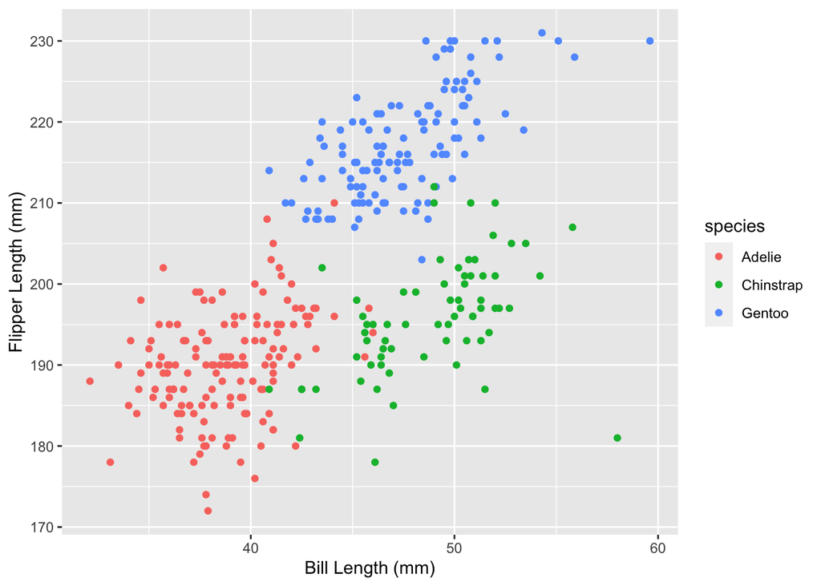

```r
penguin_length_plot = ggplot(data = penguins, aes(x = bill_length_mm, y = flipper_length_mm, color = species)) +
  geom_point() +
  xlab("Bill Length (mm)") + ylab("Flipper Length (mm)")
  penguin_length_plot
```

```r
ggsave("penguin_length_plot.pdf")
```